# Lecture 4: Nonparametric regression

Munir Hiabu

## Nonparametric regression

- Linear models are quite restrictive and one may ask how one can achieve more flexibility.
- In this lecture we will look at the nonparametric regression problem with squared loss $L(y_1,y_2)=(y_1-y_2)^2$
- We already know that the Bayes-rule is $m^\ast(x)=\mathbb E[Y|X=x]$

## Nonparametric regression k-nearest-neighbour (knn)

**Definition k-nearest-neighbour**

The k-nearest-neighbor estimator is
$$\hat m^{knn}(x)= \frac 1 k \sum_{i \in \mathcal N_k(x)}Y_i,$$
where $\mathcal N_k(x)\subseteq \{1,\dots,n\}$ contains the indices of the $k$ closest points of $\{X_1, \dots X_n\}$ to $x$.

**Definition linear smoother**

An estimator is called linear smoother if it can be written as
$$\hat m(x)= \sum_i w_i(x)Y_i,$$
where the weight function $w_i$ can depend on $\{X_1, \dots, X_n\}$.

## Nonparametric regression k-nearest-neighbour (knn)

**Example (k-nearest-neighbour)**

The k-nearest-neighbor estimator is a linear smoother:
$$\hat m^{knn}(x)= \sum_i^n w_i(x_i) Y_i,$$
with
$$w_i(x)=\begin{cases}\frac 1 k & X_i \ \text{belongs to the}\ k \ \text{closest points to}\ x \\ 0 & else\end{cases}$$

## Nonparametric regression k-nearest-neighbour (knn)

**Proposition (MSE k-nearest-neighbour)**

Assume the $E[Y|X=x]=m^\ast(x)\in \mathcal G_L = \{m: \mathbb R^p \mapsto \mathbb R| m \ \text{is L-Lipschitz continuous}\}$, and $\textrm{Var}(Y|X=x)=\sigma^2(x)\leq \sigma^2.$ Then
$$\mathbb E[(\hat m^{knn}(x)-m^\ast(x))^2]\leq (cL)^2 \left(\frac k n \right)^{2/p}+\frac {\sigma^2}k.$$
In particular, for $k_n=O_p( n^{2/(2+p)})$, we get
$$\mathbb E[(\hat m^{knn}(x)-m^\ast(x))^2]=O_p(n^{-2/(2+p)}).$$

- Note that this is slower than the “parametric” MSE of $pn^{-1}$
- In particular it now grows exponentially in $p$

## Nonparametric regression k-nearest-neighbour (knn)

**Proof MSE k-nearest-neighbour**

Write $\mathbf X=X_1,\dots, X_n$ and denote by $Y_i^{(x)}$ the $i$th closest $Y$ to $x$ among $Y_1,\dots Y_n$.
$$\begin{aligned}\mathbb E[(\hat m^{knn}(x)-m^\ast(x))^2]& =\mathbb E \Big [{\left(\mathbb{E}[\hat m^{knn}(x)|\mathbf X]-m^\ast(x)\right)^2}\Big]+{\mathbb{E}\Big[(\hat m^{knn}(x)-\mathbb{E}[\hat m^{knn}(x)|\mathbf X])^2\Big]}\\
&=\mathbb E\left[ \Big \{\frac{1}{k} \sum_{i \in \mathcal{N}_k(x)}\left(m^\ast\left(X_i\right)-m^\ast(x)\right)\Big \}^2\right] \\ &\quad + \frac 1 {k^2} \mathbb E \left[ \sum_i^k \sum_j^k \{Y_i^{(x)}- \mathbb E[Y_i^{(x)}| \mathbf X]\}\{Y_j^{(x)}- \mathbb E[Y_j^{(x)}| \mathbf X]\} \right] \\
& \leq \mathbb E\left[ \left(\frac{L}{k} \sum_{i \in \mathcal{N}_k(x)}\left\|X_i-x\right\|_2\right)^2 \right]+\frac{\sigma^2}{k} \\
&\leq^{(1)} L^2 c \left(\frac k n \right)^{2/p}+\frac {\sigma^2}k\\
\end{aligned}$$

(1) $\mathbb E\left[ \left \{\frac{1}{k} \sum_{i \in \mathcal{N}_k(x)}\left\|X_i-x\right\|_2 \right\}^2 \right]\leq c \left(\frac k n \right)^{2/p}$, see (Györfi et al. 2002, vol. 1, chap. 6.3)

## Nonparametric regression kernel smoother

- We have learned that the knn estimator can be written as
  $$\hat m^{knn}(x)= \frac 1 k w_i(x_i) Y_i,$$
- Note that $w_i(x)$ is not smooth as a function of $x$. This also makes the estimator not smooth. Given that we assume that $m^\ast$ is smooth, this may not be desirable.
- An alternative are kernel smoothers.

## Nonparametric regression kernel smoother

**Definition kernel smoother**

The kernel smoother a linear smoother with
$$\hat m^{ks}(x)= \sum_i w_i(x_i) Y_i,$$
where
$$w_i(x)=\frac{K\left(\frac{||x-X_i||}{h}\right)}{\sum_{j=1}^n K\left(\frac{||x-X_j||}{h}\right)}$$
Often $K=\prod_j k_j$, such that $K\left(\frac{||x-X_i||}{h}\right)=\prod_j k(x-X_{ij})$. The function $k: \mathbb R \mapsto \mathbb R$ is usually a symmetric density function.

## Nonparametric regression kernel smoother

**Proposition (MSE kernel smoother)**

Assume the $E[Y|X=x]=m^\ast(x)\in \mathcal G_L = \{m: \mathbb R^p \mapsto \mathbb R| m \ \text{is L-Lipschitz continuous}\}$, and $\textrm{Var}(Y|X=x)=\sigma^2(x)\leq \sigma^2.$ Then
$$\mathbb E[(\hat m^{ks}(x)-m^\ast(x))^2]= O_p\left( \frac{1}{nh^p} + h^2 \right)$$
In particular, for $h_n=O_p(n^{-1/(2+p)})$, we get
$$\mathbb E[(\hat m^{ks}(x)-m^\ast(x))^2]=O_p(n^{-2/(2+p)}).$$

## Nonparametric regression Curse of dimensionality

- We have seen that under a Lipschitz condition, both kernel smoother and knn have an asymptotic mean squared error of order $n^{-2/(2+p)}$.
- One can show that under the assumption that $m^\ast$ is twice continuously differentiable, the rate for both methods can be improved to
  $$n^{-4/(4+p)}.$$
- But this rate is still exponentially decreasing in $p$. Furthermore, it has been shown that no method can do better under the given assumptions.

## Nonparametric regression Curse of dimensionality

Here an example:

- (1) dim=1
- (2) dim=2
- (3) dim-3

We first generate 100 observations of the $x_1$ variable which is uniformly distributed on [0,10].

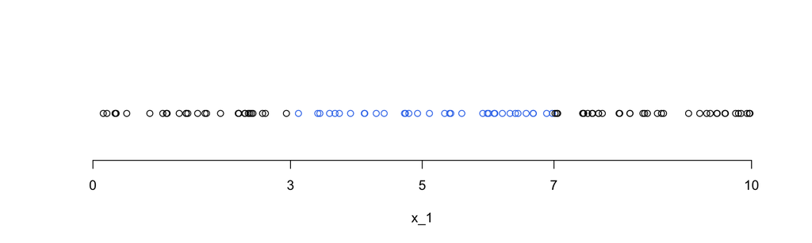

A total of 34 observations are within a distance of 2 units from the middle point 5

We generate $x_2$ independent of $x_1$ and uniformly distributed on $[0,10]$.

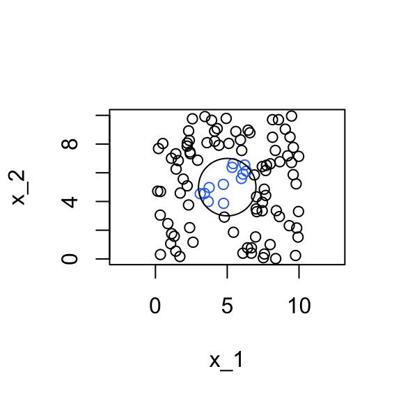

We find 12 observations within a distance of 2 units from the middle point (5,5).

The $x_3$ variable is independent of $(x_1,x_2)$ and uniformly distributed on $[0,10]$.

[interactive chart not shown]

Only a total of 1 observation(s) fall within a distance of 2 units from the middle point (5,5,5).

## Nonparametric regression Curse of dimensionality

- A new observation $x_0$ will have very few or no observations in its neighborhood
  - This leads to high variance
  - and high bias when increasing the size of the neighborhood
- Under the model of the previous slide, the setting $n=50,p=1$ has the same expected amount of observations in a neighbourhood as the setting $n=7.5\times10^{110}, p=100$.

## Nonparametric regression Curse of dimensionality

There are two ways to tackle the curse of dimensionality

### 1. Sparsity

Assume that the intrinsic dimension is lower

- E.g. Not all variables are relevant
- Or feature engineer a few highly predictive variables

### 2. Structure

Interactions are limited and structure can be exploited

- e.g. an additive structure $m(x)=m_1(x_1)+m_2(x_2).$

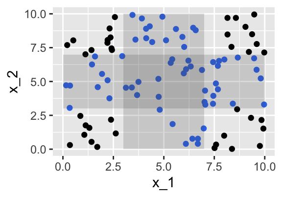

**Interpretability**

Structure is also essential for interpretability.

## Nonparametric regression Splines

- We want to establish a framework to estimate additive regression functions.
- To this end, assume $p=1$ until further notice.

**Definition (Splines)**

A $k$th-order spline with $l$ knotpoints $x_1 <\dots<x_l$

- is a polynomial of degree $k$ on each interval $(−\infty,x_1],[x_1,x_2]\dots,[x_l,\infty)$
- has continuous derivatives of orders $0,...,k-1$ on the knotpoints $x_1 <\dots<x_l$

## Nonparametric regression Splines

**Examples of splines basis**

A $k$th-order spline $m$ with $l$ knotpoints can an be uniquely written as
$$m(x)=\sum_{j=1}^{k+1+l}\theta_jg_j(x)$$

- truncated power basis
  - For $j=0,\dots, k$: $g_{j}=x^{j}$
  - For $j=k+1,\dots,k+l:$ $g_{j}=(x-x_{j-k})^k_+$
    - $(x)_+:= \max(x,0)$
- B-splines
  - more complicated, but computaitonally more robust and faster to compute.

## Nonparametric regression Natural splines

- Splines (used for regression, see next slide) have high variance at the boundaries.
- Solution: Let the piecewise polynomial function have a lower degree at $(−\infty,x_1],[x_l,\infty)$.

**Definition (Natural splines)**

A $k$th-order natural spline ($k=$ odd number) with knotpoints $x_1 <\dots<x_l$

- is a polynomial of degree $k$ on the intervals $[x_1,x_2]\dots,[x_{l-1},x_l]$
- is a polynomial of degree $(k-1)/2$ on $(−\infty,x_1],[x_l,\infty)$
- has continuous derivatives of orders $0,...,k-1$ on the knotpoints $x_1 <\dots<x_l$
- Note that natural splines have dimension $l+1$ which is in particular independent of the order $k$ (compare to dimension $k+l+1$ for splines) .
- There is also a truncated power basis and a B-splines basis for natural splines

## Nonparametric regression Linear regression with splines

- We still assume the one-dimensional case, $p=1$.
- Instead of looking at observations $(X_i,Y_i)_{i=1,\dots,n}$ we can consider a natural splines basis and look at observations $(g_1(X_i), \dots, g_{l+1}(X_i), Y_i)_{i=1,\dots,n}.$
- By doing so we are able to approximate any natural spline in $x$ instead of just linear functions in $x$, while still being in a linear regression framework, i.e.,
  $$\hat \beta = {\arg \min }_\beta \sum_i (Y_i - { G_i^T}\beta )^2= (\mathbf G^T\mathbf G)^{-1}\mathbf G^T\mathbf Y$$
  where $G_i^T=(g_1(X_i), \dots, g_{l+1}(X_i))$, the rows of $\mathbf G$.
- Problem: How do we choose the number of knotpoints $l$ and their position?
  - First thought: Cross validation. But that would be quite expensive to run.

## Nonparametric regression Smoothing splines

- Let’s look at the following minimization problem:
  $$\hat m= \arg\min_{m} \sum_i (Y_i-m(X_i))^2+\lambda\int_a^b m''(x)^2\mathrm dx,$$
  where:
  - minimization runs over all twice times differentiable functions $m$
  - observations $X_i$ are in $[a,b]$ for all $i$

## Nonparametric regression Smoothing splines

**Theorem (smoothing splines)**

If $m$ is twice differentiable and the solution to
$$\arg\min_{m} \sum_i (Y_i-m(X_i))^2+\lambda\int_a^b m''(x)^2\mathrm dx,$$
then $m$ is a natural spline of order 3 (natural cubic spline).

## Nonparametric regression Smoothing splines

**Proof**

Given a minimizer $\tilde m$, we construct the unique natural cubic spline $m$ on $[a,b]$ with knotpoints $X_1,\dots, X_n$ and $m(X_i)=\tilde m(X_i)$. We will show that $\tilde m=m$. Define $h=\tilde m-m$. Note that $h(X_j)=0 (j=1,\dots,n)$, $m'''(x)=0$ for $x<X_1$ and $x>X_n$ as well as $m^{(4)}=0$. Hence by applying integration by parts twice we get
$$\begin{aligned}
\int_a^b m''(x)h''(x)\mathrm dx
&= -\int_{X_1}^{X_n}m'''(x)h'(x)\mathrm dx \\
&= -\sum_{j=1}^{n-1}m'''(x)h(x)\Big|_{X_j}^{X_{j+1}} \\
&=0
\end{aligned}$$
This implies
$$\int_a^b \tilde m''(x)^2\mathrm dx= \int_a^b \{m''(x)+h(x)\}^2\mathrm dx=\int_a^b m''(x)^2+h(x)^2\mathrm dx.$$
meaning
$$\int_a^b m''(x)^2\mathrm dx \leq \int_a^b \tilde m''(x)^2\mathrm dx.$$
with equality only for $h''=0$, i.e, $h$ linear. Since $h(X_i)=0 (i=1,\dots n)$, we have $h=0$ and so $\tilde m=m$.

## Nonparametric regression Smoothing splines as generalized ridge regression

We can conclude the following:

- Let $\mathbf G$ be the matrix with with rows $G_i=(g_1(X_i), \dots, g_{n+1}(X_i))$.
  - $\{g_j\}_{j=1,\dots,n+1}$ is a basis for natural cubic splines with knots $X_1, \dots X_n$.
- Define

$$\hat \beta = \arg\min_{\beta} \sum_i (Y_i- G_i^T\beta)^2+\lambda\int_0^1 \left\{{\sum_j \beta_jg_j''}(x)\right\}^2\mathrm dx.$$

- Then,
  $$\sum_j \hat \beta_j g_j=\arg\min_{m} \sum_i (Y_i-m(X_i))^2+\lambda\int_0^1 m''(x)^2\mathrm dx.$$

## Nonparametric regression Smoothing splines as generalized ridge regression

Smoothing splines can be seen as a special case of generalized ridge regression:

- Write $\mathbf W_{ij}=\int_0^1g_i''(x)g_j''(x)\mathrm dx,$ then

$$\begin{aligned}
&\arg\min_{\beta} \sum_i (Y_i- G_i^T\beta)^2+\lambda\int_0^1 \left\{{\sum_j \beta_jg_j''}(x)\right\}^2\mathrm dx\\=
&\arg\min_{\beta} \sum_i (Y_i- G_i^T\beta)^2+\lambda \beta^T \mathbf W \beta.
\end{aligned}$$

- Hence,
  $$\hat \beta= (\mathbf G^T\mathbf G+\lambda \mathbf W)^{-1}\mathbf G^T\mathbf Y.$$

## Nonparametric regression Smoothing splines equivalence to kernel smoothing

- It can be shown the smoothing splines are asymptotically equivalent to kernel smoothers with varying bandwidth and a specific choice of kernel, see Silverman (1984) or Wang, Du, and Shen (2013) for a more recent contribution.
- In general, smoothing splines are more practical since they can be efficiently calculated while kernel smoothers are much easier to analyze theoretically.

## Nonparametric regression Additive models

- We have seen that fully nonparametric methods suffer from the curse of dimensionality:
  - the optimal rate of convergence for twice continuously differentiable functions is $n^{-4/(4+p)}$.
- One solution is to restrict oneself to the class of additive functions
  $$\mathcal G=\{m| m(x)=m_1(x_1)+\cdots +m_p(x_p)\}$$
- Stone (1985) showed that the components $m_k$, if twice continuously differentiable, can be estimated with one-dimensional rate of $n^{-4/4+1}$
- The components $m_j$ are usually estimated via the so called backfitting algorithm (Hastie and Tibshirani 1990).

## Nonparametric regression Additive models: backfitting

Backffitting comprises the following two steps:

**Backffiting Algorithm**

- Intialize: $\hat m_j^{[0]}=0, j=1,\dots,p$
- Iterate for $r=1,\dots$
  - Iterate for $j=1,\dots,p$
    1. Residuals: $r_{ij}^{[r]}=Y_i-\sum_{k < j} \hat{m}_{k}^{[r]}(x_{ik})-\sum_{k > j} \hat{m}_{k}^{[r-1]}(x_{ik})$.
    2. Smooth: $\hat{m}_j^{[r]}=\operatorname{Smooth}\left(\left\{X_{ij},r_{ij}^{[r]}\}_{i=1,\dots,n}\right\}\right).$
    3. Center: $\hat{m}_j^{[r]}=\hat{m}_j^{[r]}-\frac{1}{n} \sum_{i=1}^n \hat{m}_j^{[r]}\left(X_{i j}\right)$.
- Note that Smooth is a one-dimensional regression problem.
- In practice Smooth is most often a smoothing spline.
  - It has been shown backfitting via smoothing splines achieve a rate of order $p n^{-4/4+1}$.
- Problem: Additive methods are still not optimal in the case of sparsity (i.e. some features being not relevant) and interactions between features.

## References

Györfi, László, Michael Köhler, Adam Krzyżak, and Harro Walk. 2002. *A Distribution-Free Theory of Nonparametric Regression*. Vol. 1. Springer.

Hastie, T. J., and R. J. Tibshirani. 1990. *Generalized Additive Models*. Chapman & Hall/CRC Monographs on Statistics & Applied Probability. Taylor & Francis. https://books.google.dk/books?id=qa29r1Ze1coC.

Silverman, Bernard W. 1984. “Spline Smoothing: The Equivalent Variable Kernel Method.” *The Annals of Statistics*, 898–916.

Stone, Charles J. 1985. “Additive Regression and Other Nonparametric Models.” *The Annals of Statistics* 13 (2): 689–705.

Wang, Xiao, Pang Du, and Jinglai Shen. 2013. “Smoothing Splines with Varying Smoothing Parameter.” *Biometrika* 100 (4): 955–70.